# HaVu_hw5

Vu Thi-Hong-Ha

April 28, 2020

### Part 1

```r
gbm <- mydata
annot <- desx
annot$class <- as.character(annot$class)
annot[is.na(annot$class), 1] <- "NA"
```

**PCA**

```r
gbm.pca <- prcomp(t(gbm), center = T, scale. = T)
summary(gbm.pca)$importance[, 1:10]
```

```
##                             PC1      PC2      PC3      PC4      PC5      PC6
## Standard deviation     19.21202 12.91715 12.08550 10.92909 9.190443 8.002174
## Proportion of Variance  0.21213  0.09589  0.08394  0.06865 0.048540 0.036800
## Cumulative Proportion   0.21213  0.30802  0.39196  0.46061 0.509150 0.545950
##                             PC7      PC8      PC9     PC10
## Standard deviation     7.417361 6.893661 6.570695 6.524037
## Proportion of Variance 0.031620 0.027310 0.024810 0.024460
## Cumulative Proportion  0.577570 0.604880 0.629700 0.654160
```

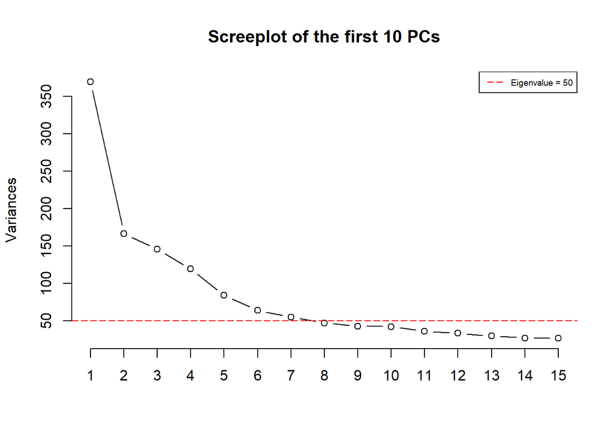

```r
#Scree plot for PCA
screeplot(gbm.pca, type = "l", npcs = 15, main = "Screeplot of the first 10 PCs")
abline(h = 50, col = "red", lty = 5)
legend("topright", legend = c("Eigenvalue = 50"), col = c("red"), lty = 5, cex = 0.6)
```

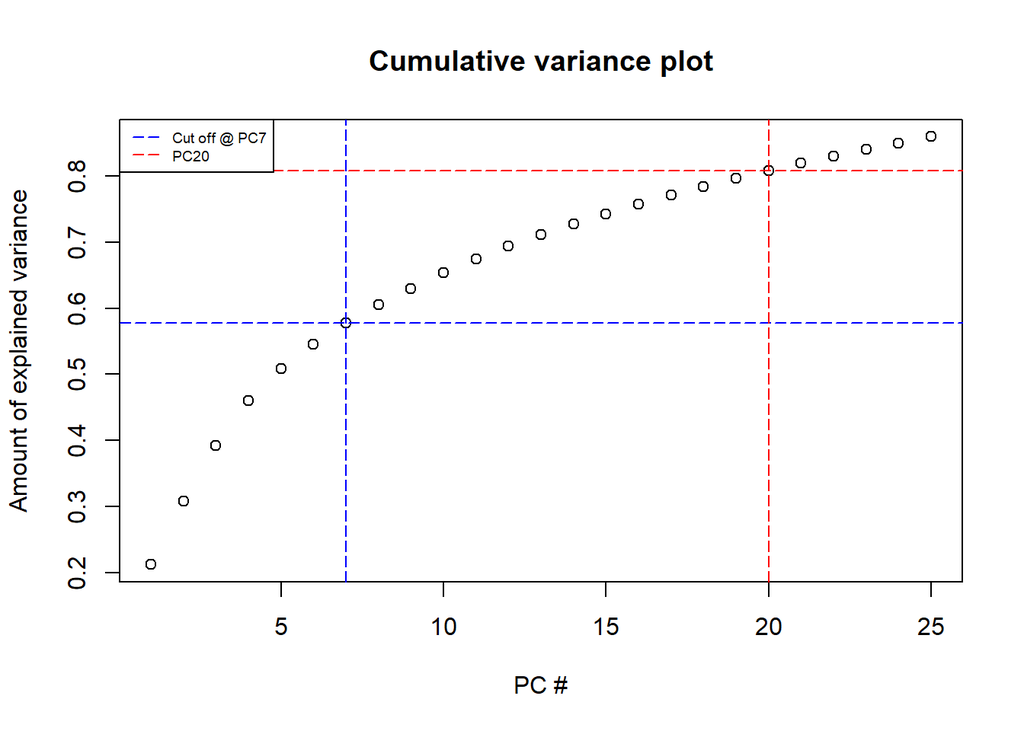

```r
cumpro <- cumsum(gbm.pca$sdev^2 / sum(gbm.pca$sdev^2))
plot(cumpro[0:25], xlab = "PC #", ylab = "Amount of explained variance", main = "Cumulative variance plot")
abline(v = 7, col = "blue", lty = 5)
abline(h = 0.57757, col = "blue", lty = 5)
abline(v = 20, col = "red", lty = 5)
abline(h = 0.80822, col = "red", lty = 5)
legend("topleft", legend = c("Cut off @ PC7", "PC20"),
       col = c("blue", "red"), lty = 5, cex = 0.6)
```

By this screeplot, I choose to cut off at PC7. However, the first 20 PCs are only enough to explain ~80% of the data set. Next I use `facoextra` and `M3C` libraries to plot the first 2 PCs. We can see that they are slightly different in the number of percentages the first 2 PCs can capture.

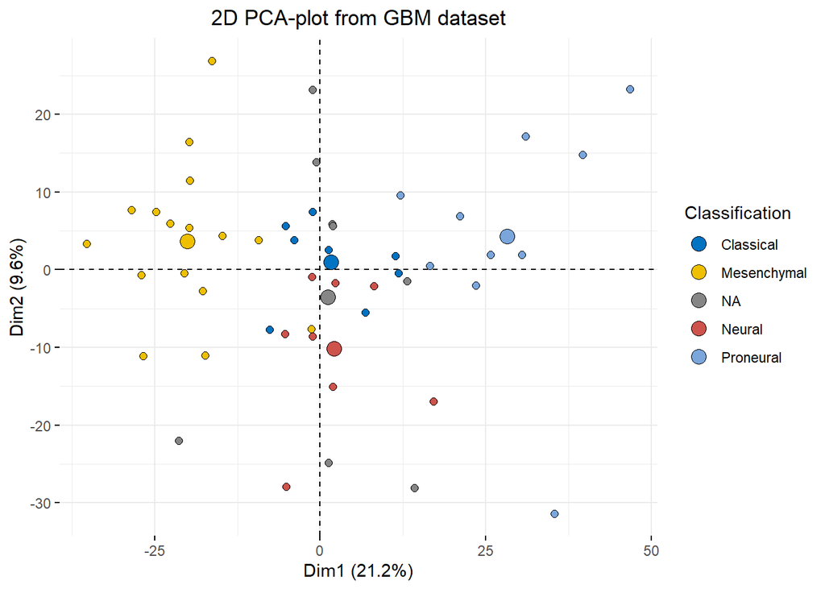

```r
# plots PCs 1 and 2 labelled
factoextra::fviz_pca_ind(gbm.pca, geom = "point", pointshape = 21, pointsize = 2,
                         fill.ind = annot$class, palette = "jco",
                         addEllipses = FALSE, repel = TRUE,
                         legend.title = "Classification") +
  ggtitle("2D PCA-plot from GBM dataset") +
  theme(plot.title = element_text(hjust = 0.5))
```

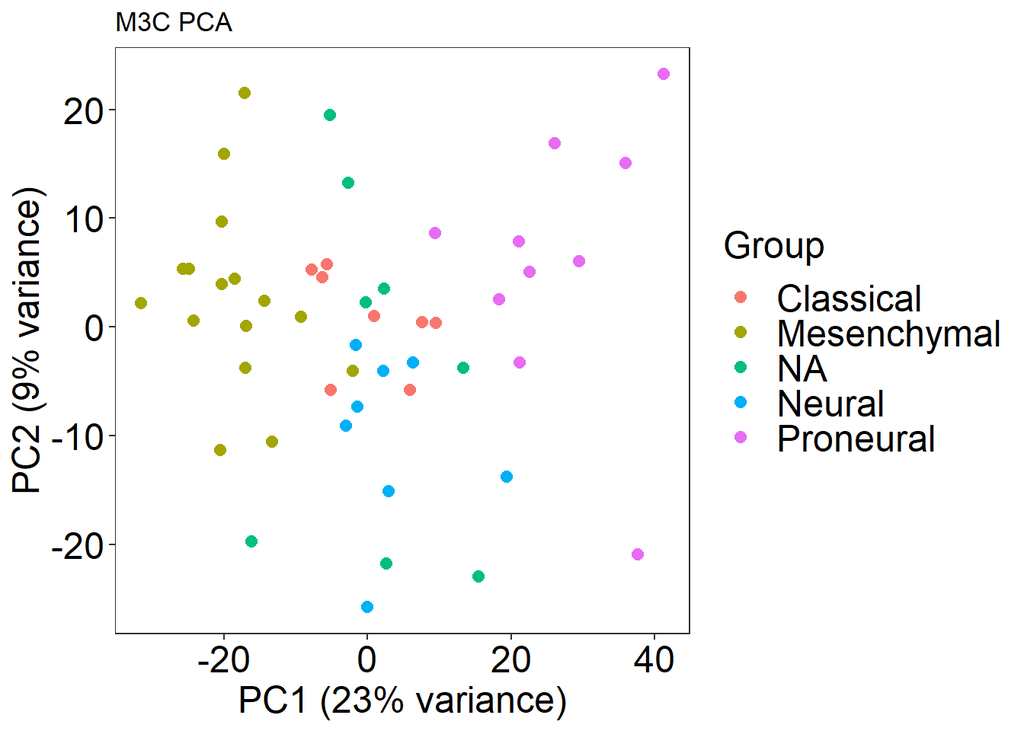

```r
M3C::pca(gbm, labels = as.factor(annot$class), dotsize = 2.5) + ggtitle("M3C PCA") #slightly different from prcomp()
```

In general, `Mesenchymal`, `Neural`, `Proneural` and `Classical` are quite separate, with `Classical` and `Neural` are somewhat mixed up. The cells that we don’t have any information about (i.e. `NA`) are scattering all over the plots.

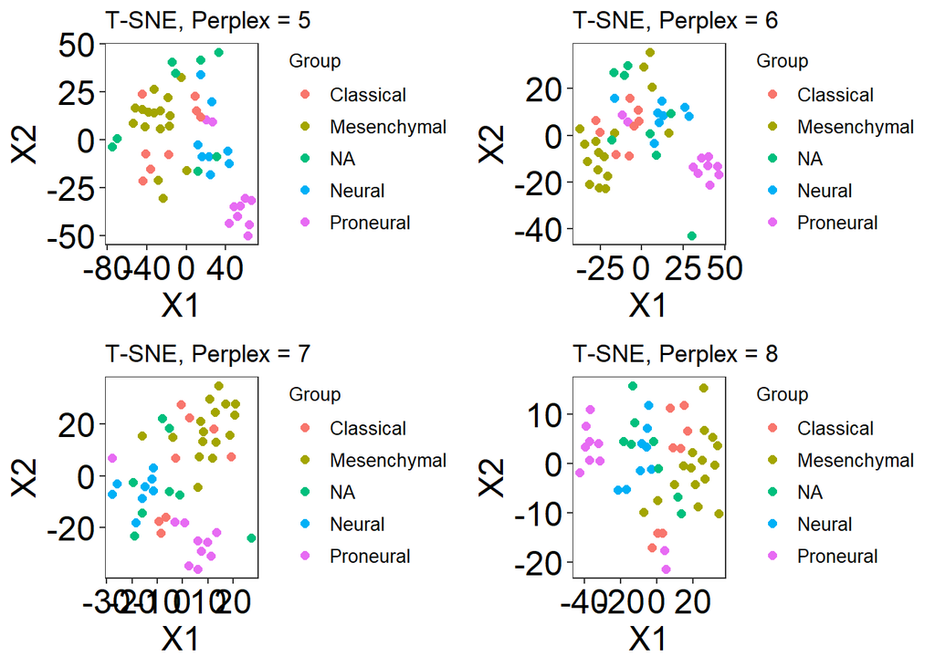

```r
###T-SNE
#16 is max perplexity
gbm.tsne5 <- tsne(gbm, perplex = 5, dotsize = 2, labels = as.factor(annot$class), legendtextsize = 10) + ggtitle("T-SNE, Perplex = 5")
gbm.tsne6 <- tsne(gbm, perplex = 6, dotsize = 2, labels = as.factor(annot$class), legendtextsize = 10) + ggtitle("T-SNE, Perplex = 6")
gbm.tsne7 <- tsne(gbm, perplex = 7, dotsize = 2, labels = as.factor(annot$class), legendtextsize = 10) + ggtitle("T-SNE, Perplex = 7")
gbm.tsne8 <- tsne(gbm, perplex = 8, dotsize = 2, labels = as.factor(annot$class), legendtextsize = 10) + ggtitle("T-SNE, Perplex = 8")
gbm.tsne9 <- tsne(gbm, perplex = 9, dotsize = 2, labels = as.factor(annot$class), legendtextsize = 10) + ggtitle("T-SNE, Perplex = 9")
gbm.tsne10 <- tsne(gbm, perplex = 10, dotsize = 2, labels = as.factor(annot$class), legendtextsize = 10) + ggtitle("T-SNE, Perplex = 10")
gbm.tsne11 <- tsne(gbm, perplex = 11, dotsize = 2, labels = as.factor(annot$class), legendtextsize = 10) + ggtitle("T-SNE, Perplex = 11")
gbm.tsne12 <- tsne(gbm, perplex = 12, dotsize = 2, labels = as.factor(annot$class), legendtextsize = 10) + ggtitle("T-SNE, Perplex = 12")
gbm.tsne13 <- tsne(gbm, perplex = 13, dotsize = 2, labels = as.factor(annot$class), legendtextsize = 10) + ggtitle("T-SNE, Perplex = 13")
gbm.tsne14 <- tsne(gbm, perplex = 14, dotsize = 2, labels = as.factor(annot$class), legendtextsize = 10) + ggtitle("T-SNE, Perplex = 14")
gbm.tsne15 <- tsne(gbm, perplex = 15, dotsize = 2, labels = as.factor(annot$class), legendtextsize = 10) + ggtitle("T-SNE, Perplex = 15")
gbm.tsne16 <- tsne(gbm, perplex = 16, dotsize = 2, labels = as.factor(annot$class), legendtextsize = 10) + ggtitle("T-SNE, Perplex = 16")

grid.arrange(gbm.tsne5, gbm.tsne6, gbm.tsne7, gbm.tsne8, nrow = 2, ncol = 2)
```

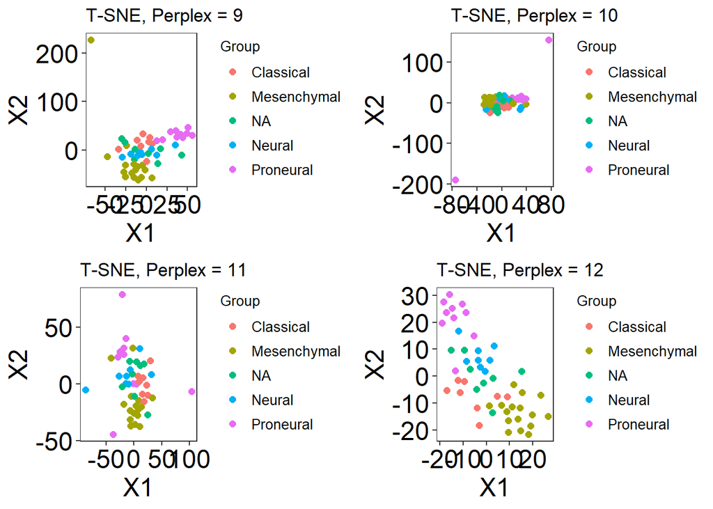

```r
grid.arrange(gbm.tsne9, gbm.tsne10, gbm.tsne11, gbm.tsne12, nrow = 2, ncol = 2)
```

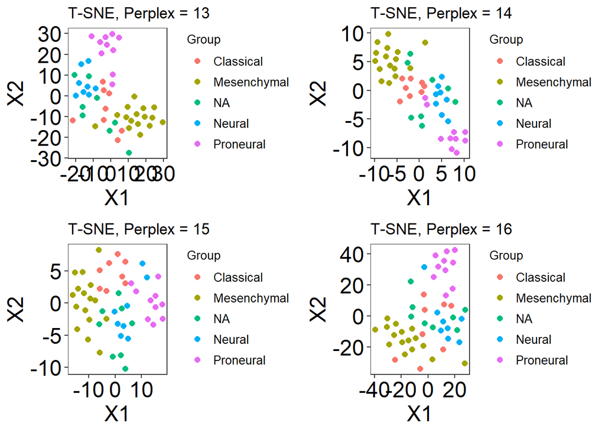

```r
grid.arrange(gbm.tsne13, gbm.tsne14, gbm.tsne15, gbm.tsne16, nrow = 2, ncol = 2)
```

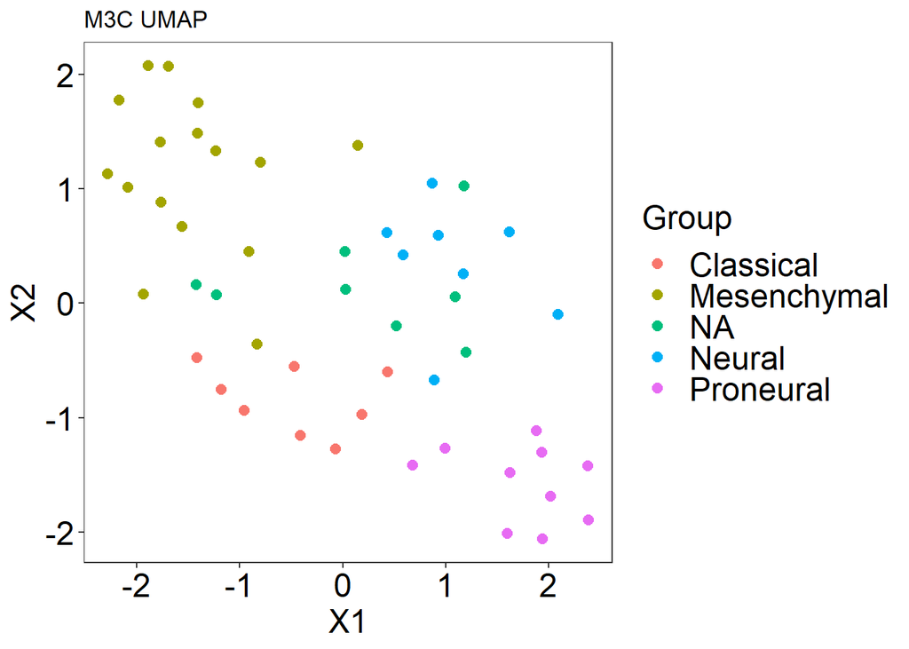

```r
###UMAP
umap(gbm, labels = as.factor(annot$class), dotsize = 2.5) + ggtitle("M3C UMAP")
```

With the above plots, we can see that higher perplexity is better in this case. Both T-SNE and UMAP plots agree with PCA.

### Part 2

For this part, I’m going to test `RunUMAP` fuction of library `Seurat`, so I save the count data into 2 tables. For the filtering, I remove genes that have 0 counts across all samples. I then log transform the data.

```r
load("D:/Coursework/BCB 570 Spring 2020/Homework5/dimRed.RData/dimRed.RData")
names(Biocond_High) <- colnames(counts_hi)
counts_hi <- counts_hi[rowSums(counts_hi != 0) != 0,]

countsSEURAT <- counts_hi

counts_hi <- log(counts_hi + 1) #M3C
```

**PCA**

```r
###PCA
high.pca <- prcomp(t(counts_hi), center = T, scale. = T)
summary(high.pca)$importance[, 1:10]
```

```
##                             PC1      PC2      PC3      PC4      PC5      PC6
## Standard deviation     33.54999 24.99895 21.35047 20.60532 20.06175 19.20824
## Proportion of Variance  0.06596  0.03662  0.02671  0.02488  0.02358  0.02162
## Cumulative Proportion   0.06596  0.10258  0.12929  0.15417  0.17776  0.19938
##                             PC7      PC8      PC9     PC10
## Standard deviation     18.49825 18.37952 18.08772 17.84266
## Proportion of Variance  0.02005  0.01980  0.01917  0.01866
## Cumulative Proportion   0.21943  0.23923  0.25840  0.27705
```

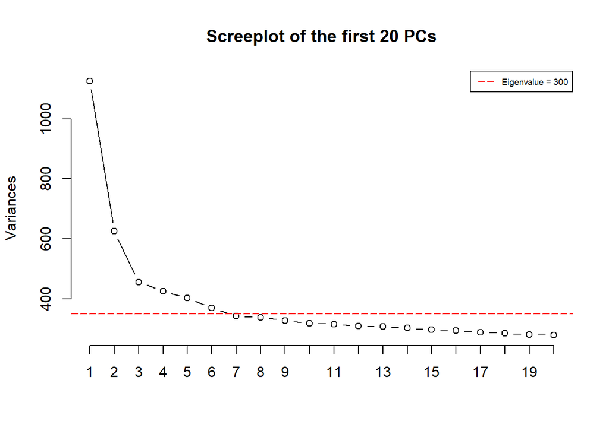

```r
#Scree plot for PCA
screeplot(high.pca, type = "l", npcs = 20, main = "Screeplot of the first 20 PCs")
abline(h = 350, col = "red", lty = 5)
legend("topright", legend = c("Eigenvalue = 300"), col = c("red"), lty = 5, cex = 0.6)
```

The data is complex, and the first 10 PCs can only capture a small portion of the data. This suggests PCA might not be a suitable grouping method. I chose the PC cut off to be PC7. Let’s look at the plot.

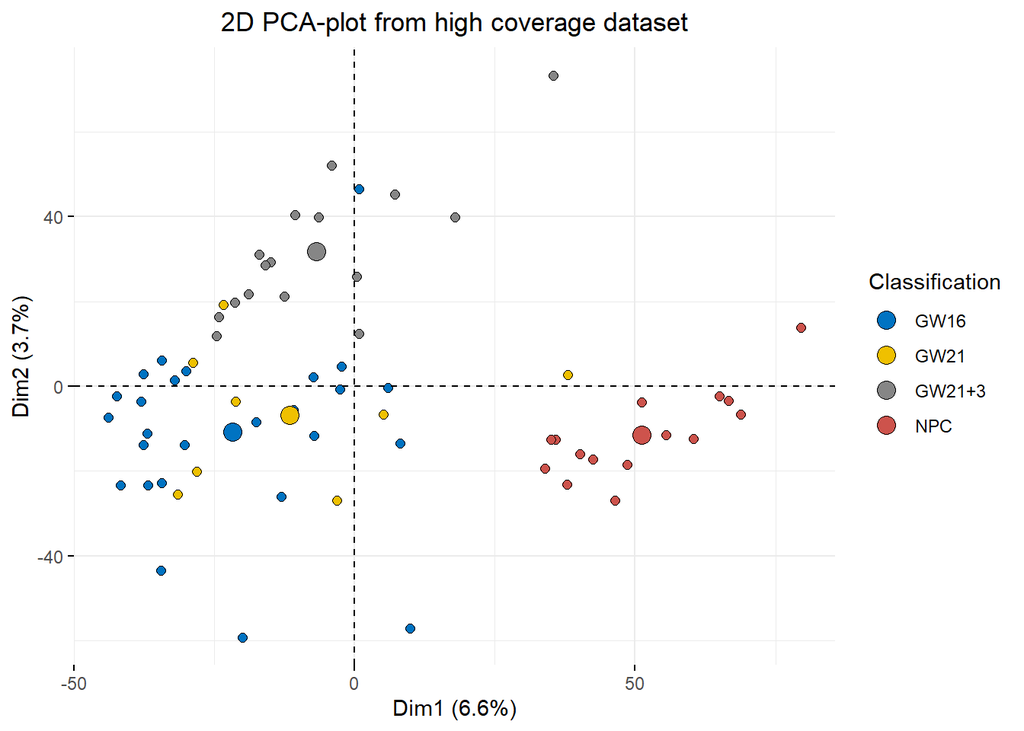

```r
# plots PCs 1 and 2 labelled
factoextra::fviz_pca_ind(high.pca, geom = "point", pointshape = 21, pointsize = 2,
                         fill.ind = as.factor(Biocond_High), palette = "jco",
                         addEllipses = FALSE, repel = TRUE,
                         legend.title = "Classification") +
  ggtitle("2D PCA-plot from high coverage dataset") +
  theme(plot.title = element_text(hjust = 0.5))
```

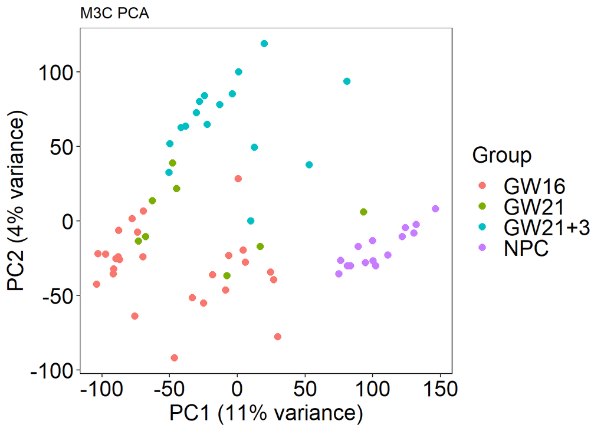

```r
M3C::pca(counts_hi, labels = as.factor(Biocond_High), dotsize = 2.5) + ggtitle("M3C PCA")
```

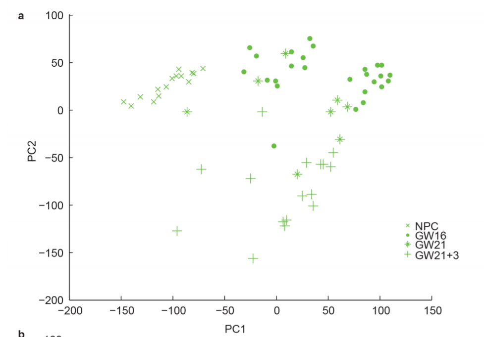

**T-SNE**

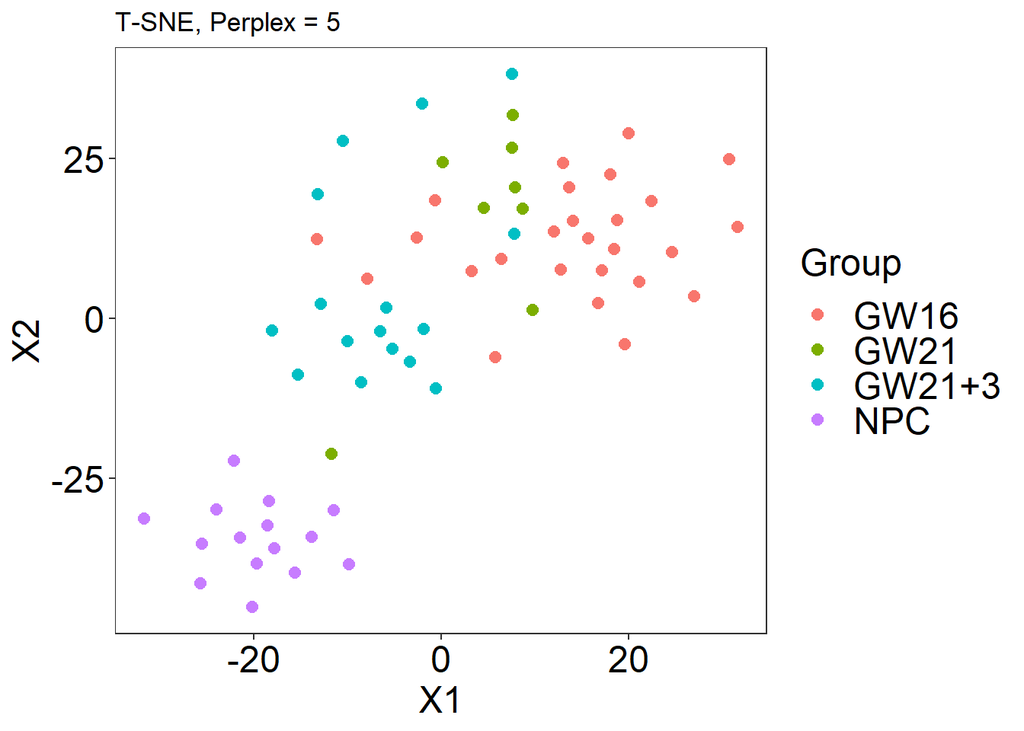

```r
##T-SNE
tsne(counts_hi, labels = as.factor(Biocond_High), perplex = 5, dotsize = 2.5) + ggtitle("T-SNE, Perplex = 5")
```

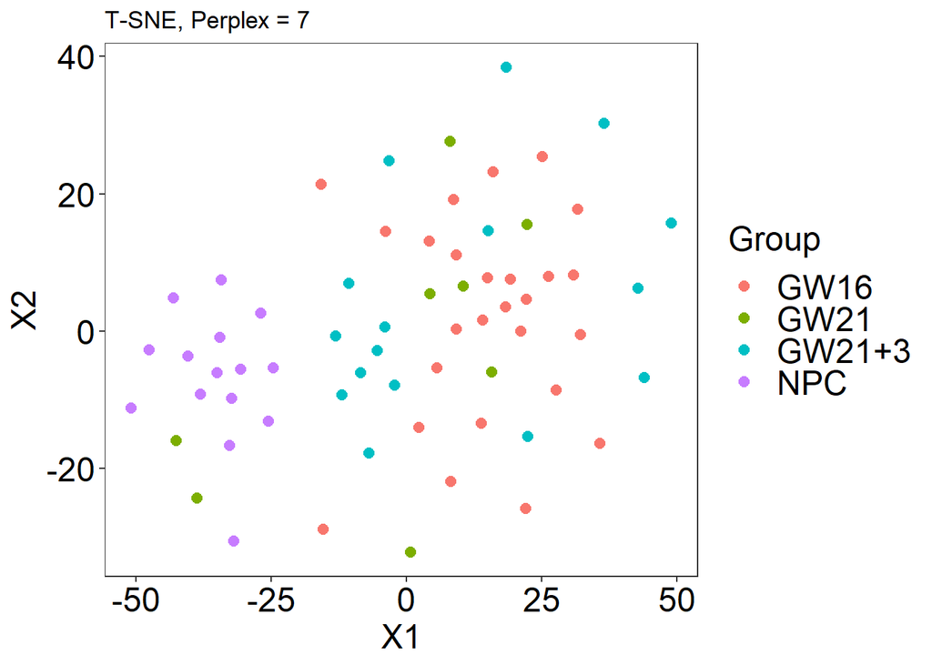

```r
tsne(counts_hi, labels = as.factor(Biocond_High), perplex = 7, dotsize = 2.5) + ggtitle("T-SNE, Perplex = 7")
```

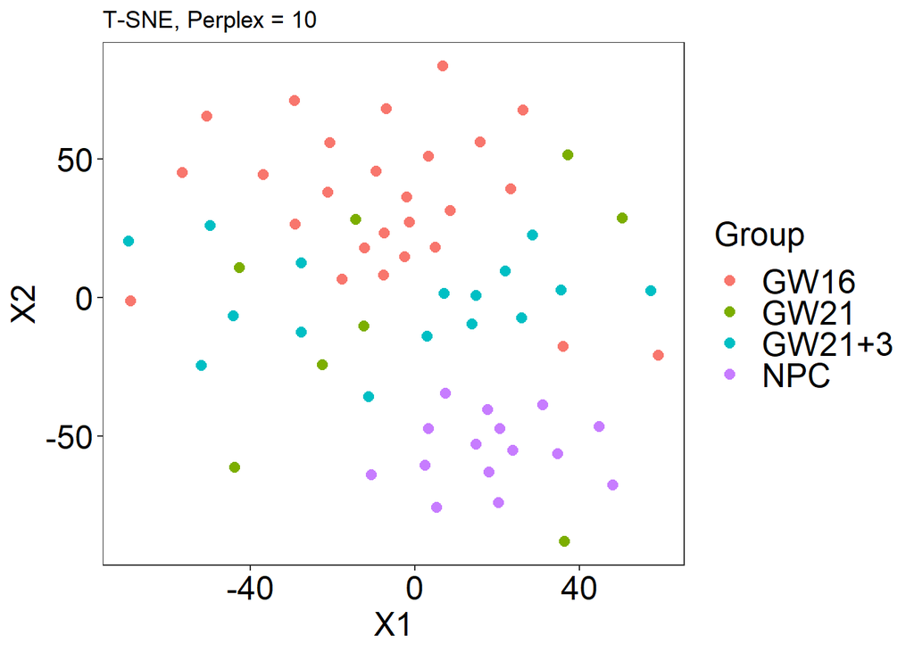

```r
tsne(counts_hi, labels = as.factor(Biocond_High), perplex = 10, dotsize = 2.5) + ggtitle("T-SNE, Perplex = 10")
```

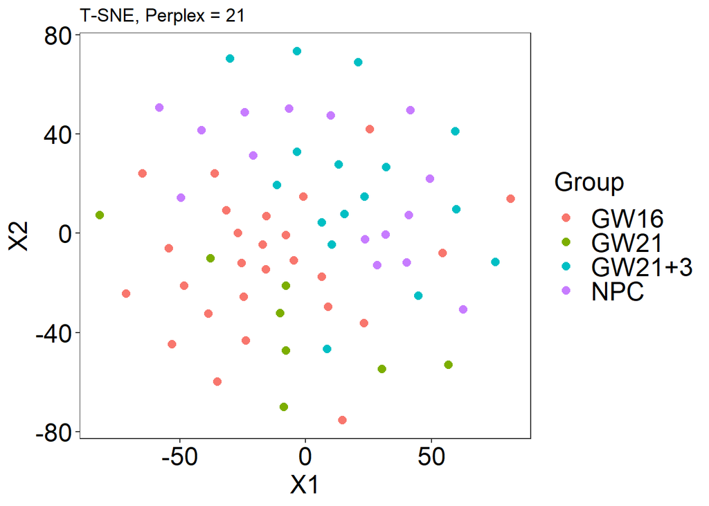

```r
tsne(counts_hi, labels = as.factor(Biocond_High), perplex = 21, dotsize = 2.5) + ggtitle("T-SNE, Perplex = 21") #max perplexity
```

**UMAP**

For this part, I will test out `Seurat` package also. As far as I know, `RunUMAP` in `Seurat` only serves as a plot function, but the underlying grouping method relies heavily on the functions `FindNeighbots` and `FindClusters`. I notice that these two functions do not separate the samples according to cell types, although the separation is close. Please refer to the following code and plots:

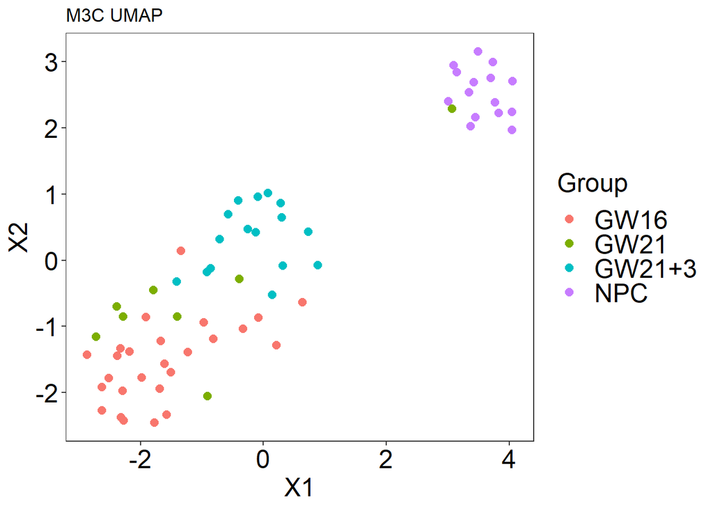

```r
##UMAP
M3C::umap(counts_hi, labels = as.factor(Biocond_High), dotsize = 2.5) + ggtitle("M3C UMAP")
```

```r
##UMAP
neurals <- CreateSeuratObject(countsSEURAT, meta.data = as.data.frame(Biocond_High))

features <- rownames(countsSEURAT)
neurals <- NormalizeData(neurals)
neurals <- ScaleData(neurals, features = features)

neurals <- RunPCA(neurals, features = features)

neurals <- FindNeighbors(neurals, dims = 1:7)
neurals <- FindClusters(neurals, resolution = 1.2)
```

```
## Modularity Optimizer version 1.3.0 by Ludo Waltman and Nees Jan van Eck
##
## Number of nodes: 65
## Number of edges: 1620
##
## Running Louvain algorithm...
## Maximum modularity in 10 random starts: 0.1971
## Number of communities: 4
## Elapsed time: 0 seconds
```

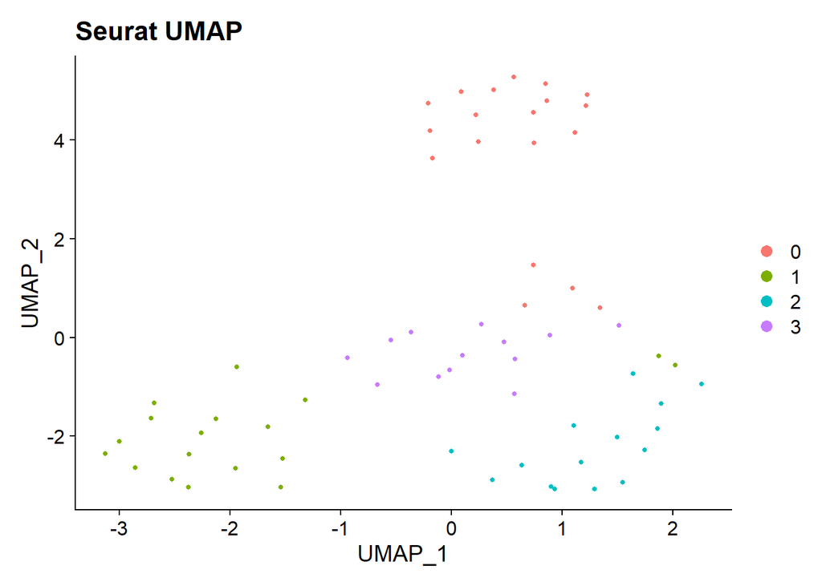

```r
neurals <- RunUMAP(neurals, dims = 1:7)
DimPlot(neurals, reduction = "umap") + ggtitle("Seurat UMAP")
```

```r
head(Idents(neurals), 5)
```

```
## SRR1275356 SRR1275251 SRR1275287 SRR1275364 SRR1275269
##          2          2          3          2          0
## Levels: 0 1 2 3
```

```r
unique(Biocond_High[which(Idents(neurals) == 0)])
```

```
## [1] "GW21" "NPC"  "GW16"
```

```r
unique(Biocond_High[which(Idents(neurals) == 1)])
```

```
## [1] "GW21+3" "GW21"
```

```r
unique(Biocond_High[which(Idents(neurals) == 2)])
```

```
## [1] "GW16" "GW21"
```

```r
unique(Biocond_High[which(Idents(neurals) == 3)])
```

```
## [1] "GW21+3" "GW16"
```